# Initial GTEX Analysis

David Gerard

2016-05-27

# Brief Summary

Read in the cleaned heart gtex data and estimate the number of hidden confounders with `sva::num.sv()`.

```r
library(ggplot2)
load(file = "../output/cleaned_gtex_data/heart.Rd")
k <- sva::num.sv(dat = heart$Y, mod = heart$X)
k
```

```
## [1] 22
```

$Y$ is log(COUNTS + 1) of the top 19939 expressed genes (genes with at least 10 reads per sample on average). Samples from the same individual were averaged, resulting in $n =$ 293. $X$ contains just an intercept and an indicator for gender. The idea here is that genes on sex chromosomes are “positive controls,” so the best method will be that which has the most genes on sex chromosomes among the most significant genes. This is the setup that Gagnon-Bartsch and Speed (2012) and Wang et al. (2015) use to evaluate performance between these confounder adjustment methods.

Control genes are the housekeeping genes identified by Eisenberg and Levanon (2013). This is a different list than that used by Gagnon-Bartsch and Speed (2012), which was drawn from Eisenberg and Levanon (2003). In total, there are 3609 housekeeping genes among the 19939 most expressed genes in the GTEX heart data.

# Analysis

## RUVASH vs RUV4

Now fit RUVASH and RUV4.

```r
qthresh <- 0.05
onsex <- heart$chrom == "X" | heart$chrom == "Y"
ruvash_out <- ashr::ash_ruv(Y = t(heart$Y), X = heart$X, ctl = heart$ctl, k = k)
ruvash_onsex <- onsex[order(ruvash_out$lfdr)]
ruv4_out <- ruv::RUV4(Y = t(heart$Y), X = heart$X[, 2, drop = FALSE], ctl = heart$ctl, k = k)
ruv4_onsex <- onsex[order(ruv4_out$p)]
num_sig <- sum(ruvash_out$qvalue < qthresh)
qout <- qvalue::qvalue(p = ruv4_out$p)
num_sig_ruv4 <- sum(qout$qvalue < qthresh)
```

The orderings that RUVASH and RUV4 give for the most significant genes are very similar. RUVASH says that 62 genes have a q-value less than 0.05. RUVASH says that 45 of the top 62 genes are on a sex chromosome while RUV4 says that 45 of the top 62 genes are on a sex chromosome. We can calculate the Kendall’s tau of the rankings that RUV4 and RUVASH give for the top 62 genes:

```r
lfdr_order <- order(ruvash_out$lfdr)
tau <- cor(c(ruv4_out$p)[lfdr_order[1:num_sig]], ruvash_out$lfdr[lfdr_order[1:num_sig]], method = "kendall")
tau
```

```
## [1] 0.9414
```

Their rankings don’t differ that much in the first 62 genes. The ordering later on gets a very different.

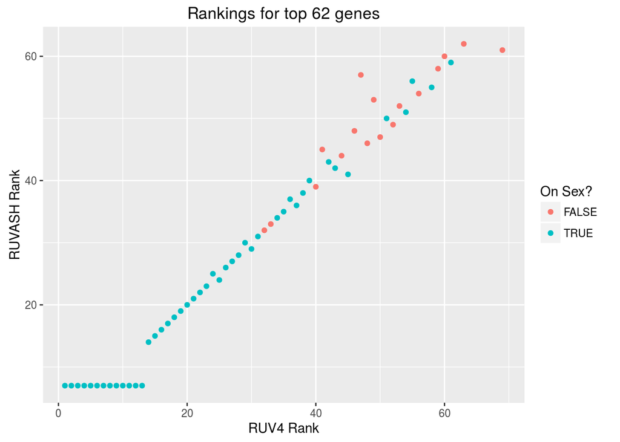

```r
qplot(rank(c(ruv4_out$p))[lfdr_order[1:num_sig]], rank(ruvash_out$lfdr)[lfdr_order[1:num_sig]],
      xlab = "RUV4 Rank", ylab = "RUVASH Rank",
      main = paste("Rankings for top", num_sig, "genes"),
      color = onsex[lfdr_order[1:num_sig]]) +
    guides(color=guide_legend(title="On Sex?"))
```

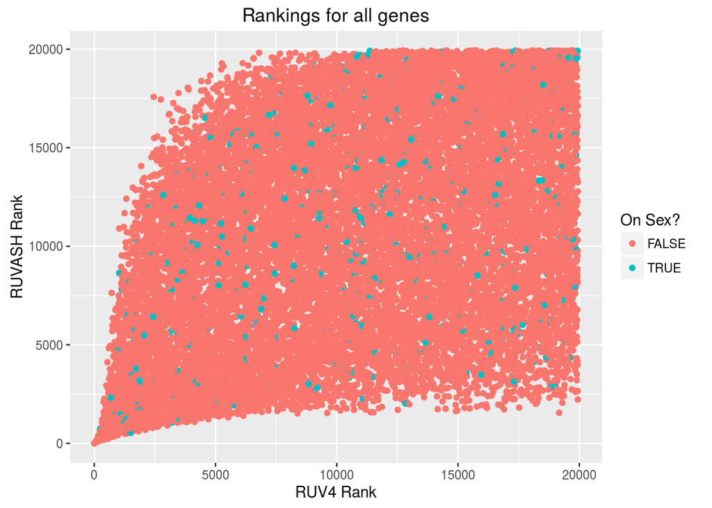

```r
qplot(rank(c(ruv4_out$p)), rank(ruvash_out$lfdr),
      xlab = "RUV4 Rank", ylab = "RUVASH Rank",
      main = "Rankings for all genes",
      color = onsex[lfdr_order]) +
    guides(color=guide_legend(title="On Sex?"))
```

However, I am going to argue that RUVASH is much better calibrated than RUV4. RUV4, followed by using `qvalue` (Storey 2003), estimates $\pi_0$ to be 0.6762 against RUVASH’s estimated $\pi_0$ of 0.9945. I think RUVASH’s estimate is much more realistic in this scenario as 0.9666 of the genes are not on a sex chromosome, so one would think that $\pi_0$ is closer to this value. Furthermore, RUV4 + `qvalue` says that 1805 genes have a q-value less than 0.05, compared to RUVASH’s estimate of 62. The proportion of the top 62 RUVASH genes on a sex chromosome is 0.7258. The proportion of the top 1805 RUV4 genes on a sex chromosome is 0.0859, which seems like very poor performance.

There seems to be a shift from sex-chromosome genes to non-sex chromosome right around the significance cutoff for RUVASH.

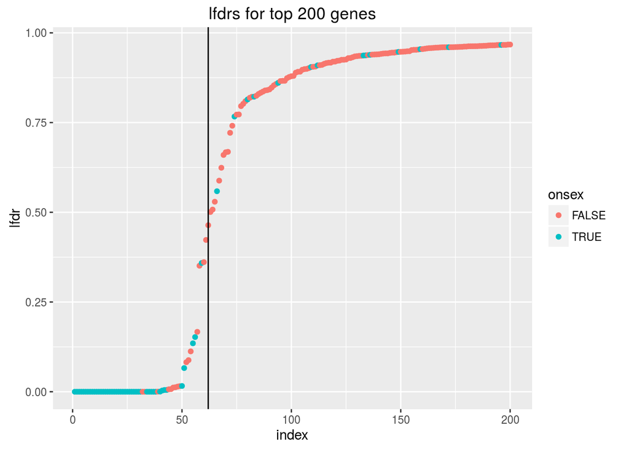

```r
num_plot <- 200
df_lfdr <- data.frame(lfdr = ruvash_out$lfdr[lfdr_order][1:num_plot],
                      qvalue = ruvash_out$qvalue[lfdr_order][1:num_plot],
                      onsex = ruvash_onsex[1:num_plot],
                      index = 1:num_plot)
ggplot(data = df_lfdr, mapping = aes(y = lfdr, x = index, color = onsex)) + geom_point() +
    geom_vline(xintercept = num_sig) +
    ggtitle(paste("lfdrs for top", num_plot, "genes"))
```

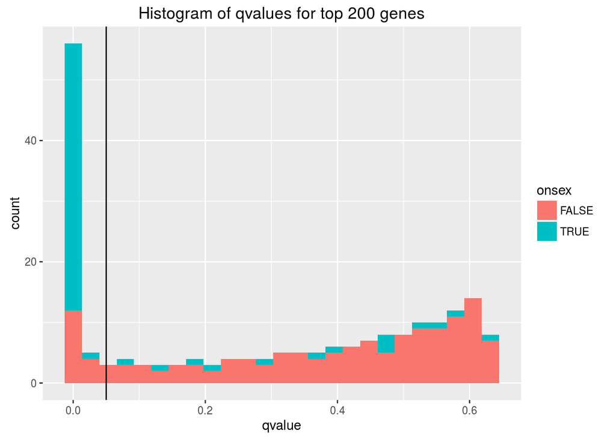

```r
ggplot(data = df_lfdr, mapping = aes(x = qvalue, fill = onsex)) + geom_histogram(bins = 25) +
    geom_vline(xintercept = qthresh) +
    ggtitle(paste("Histogram of qvalues for top", num_plot, "genes"))
```

RUV4 is not having a problem with the p-value distribution. Indeed, it looks pretty good:

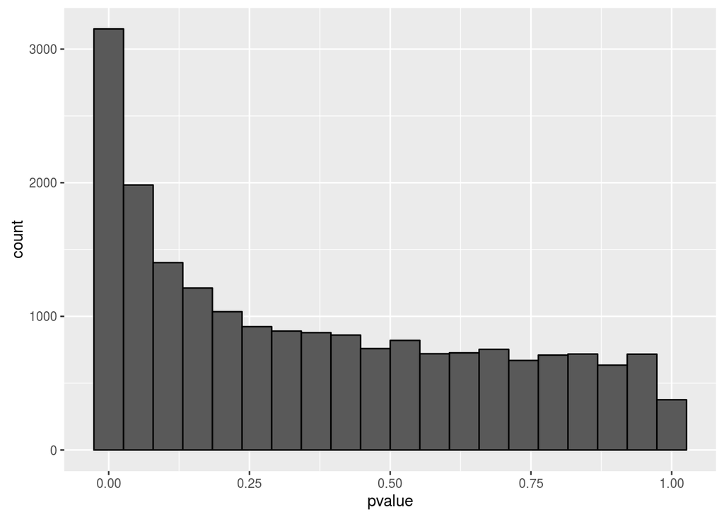

```r
ggplot(data = data.frame(pvalue = c(ruv4_out$p)), aes(x = pvalue, color = I("black"))) +
    geom_histogram(, bins = 20)
```

The t-statistics for the genes that RUVASH says is null match up pretty well against a standard normal.

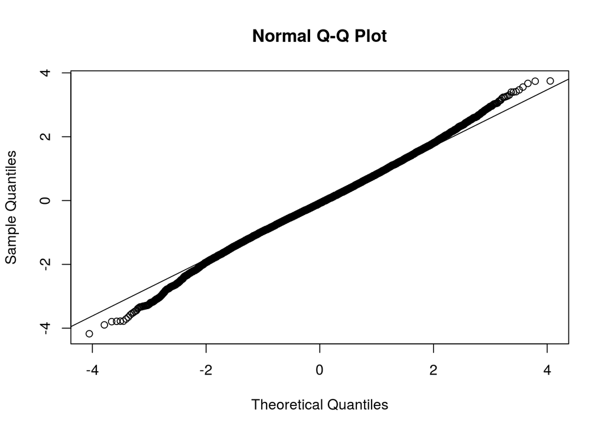

```r
sig_genes <- ruvash_out$qvalue < 0.05
tstat <- ruvash_out$ruv$betahat / ruvash_out$ruv$sebetahat
qqnorm(tstat[!sig_genes])
qqline(tstat[!sig_genes])
```

## ASH using RUV4 without the variance inflation.

The variance inflation for RUVASH is very high, being 3.8673. We can fit ASH using the output from RUV4 and see what comes out.

```r
betahat   <- ruv4_out$betahat
sebetahat <- sqrt(ruv4_out$sigma * ruv4_out$multiplier)
ash_out <- ashr::ash(betahat = betahat, sebetahat = sebetahat)
ash_out$fitted.g$pi[1] ## estimate of pi0
```

```
## [1] 0.2673
```

which is even lower than that provided by `qvalue`.

## RUV4, ASH and other choices of number of confounders.

It has been suggested that if I try different numbers of confounders, then RUV4 and ash might perform better. Rather, that the variance inflation is needed mostly because I am not estimating the number of hidden confounders accurately. If I run RUV4 with different choices of number of hidden confounders, I always get estimates of $\pi_0$ very far from what RUVASH is giving me. The RUVASH estimate seems more reasonable given the proportion of genes on sex chromosomes.

```r
maxk <- 50
pi0mat_q <- matrix(NA, nrow = maxk + 1, ncol = 3)
for (index in 0:maxk) {
    ruv4_out <- ruv::RUV4(Y = t(heart$Y), X = heart$X[, 2, drop = FALSE],
                          ctl = heart$ctl, k = index)
    qout <- qvalue::qvalue(ruv4_out$p)
    betahat   <- ruv4_out$betahat
    sebetahat <- sqrt(ruv4_out$sigma * ruv4_out$multiplier)
    ash_out <- ashr::ash(betahat = betahat, sebetahat = sebetahat)
    pi0mat_q[index + 1, 1] <- qout$pi0
    pi0mat_q[index + 1, 2] <- ash_out$fitted.g$pi[1]
    pi0mat_q[index + 1, 3] <- index
}
```

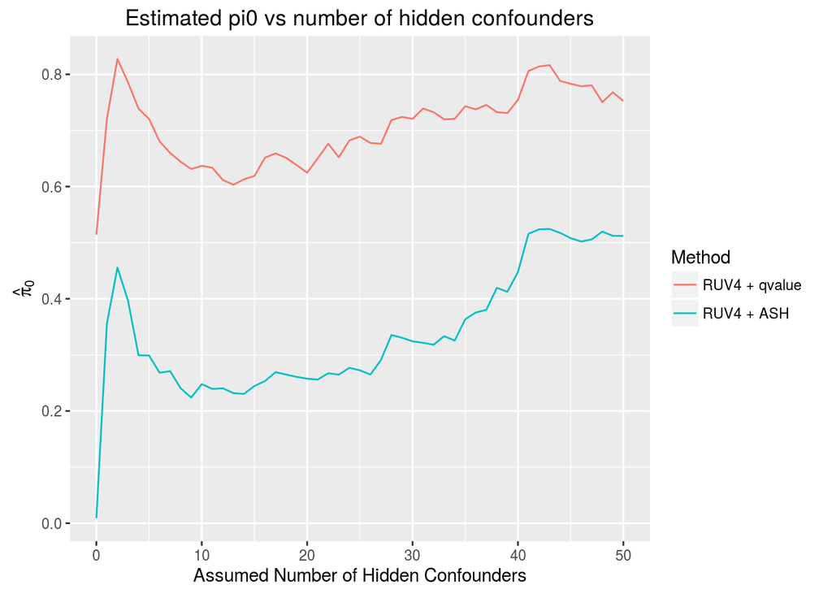

```r
colnames(pi0mat_q) <- c("RUV4andQvalue", "RUV4andASH", "num_confounder")
longdat <- reshape2::melt(as.data.frame(pi0mat_q), id.vars = "num_confounder")
ggplot(data = longdat, aes(y = value, x = num_confounder, color = variable)) +
    geom_line() + ylab(expression(hat(pi)[0])) +
    xlab("Assumed Number of Hidden Confounders") +
    ggtitle("Estimated pi0 vs number of hidden confounders") +
    guides(color=guide_legend(title="Method")) +
    scale_color_discrete(labels = c("RUV4 + qvalue", "RUV4 + ASH"))
```

Recall that the `num.sv` estimated the number of hidden confounders to be 22 and the estimate of $\pi_0$ given by RUVASH is 0.9945.

## What About OLS + Limma?

```r
ols_out <- limma::lmFit(object = heart$Y, design = heart$X)
lim_out <- limma::ebayes(fit = ols_out)
lim_p <- lim_out$p.value[, 2]
lim_onsex <- onsex[order(lim_p)]
```

Limma says that 38 of the top 62 are on a sex chromosome. The ordering of genes via Limma and RUVASH are very different.

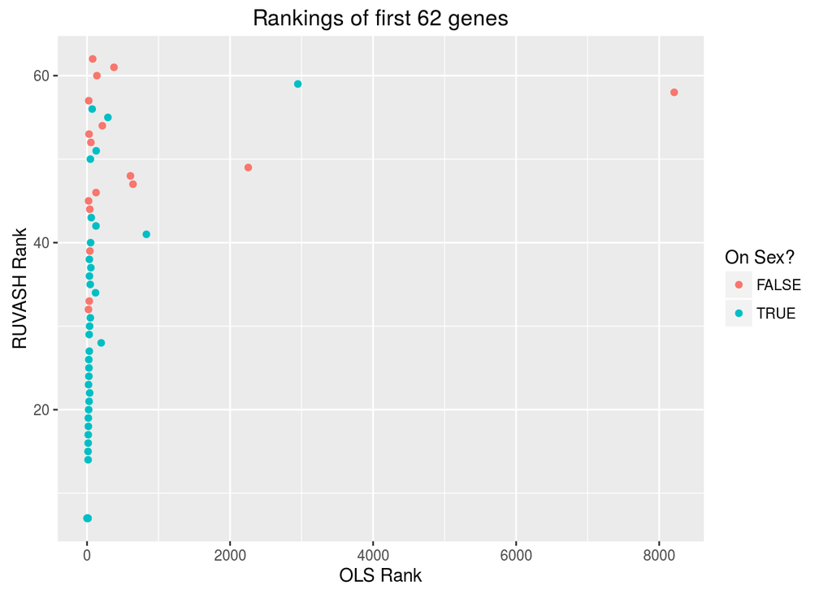

```r
qplot(rank(c(lim_p))[lfdr_order[1:num_sig]], rank(ruvash_out$lfdr)[lfdr_order[1:num_sig]],
      xlab = "OLS Rank", ylab = "RUVASH Rank", main = paste("Rankings of first", num_sig, "genes"),
      color = onsex[lfdr_order[1:num_sig]]) +
    guides(color=guide_legend(title="On Sex?"))
```

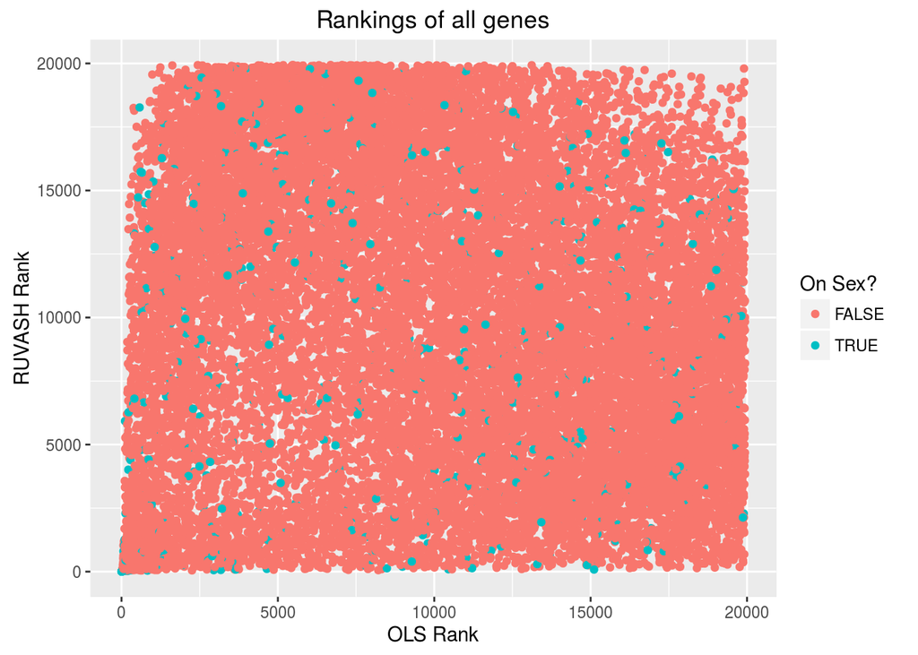

```r
qplot(rank(c(lim_p)), rank(ruvash_out$lfdr),
      xlab = "OLS Rank", ylab = "RUVASH Rank", main = paste("Rankings of all genes"),
      color = onsex) +
    guides(color=guide_legend(title="On Sex?"))
```

# References

Eisenberg, Eli, and Erez Y Levanon. 2003. “Human Housekeeping Genes Are Compact.” *TRENDS in Genetics* 19 (7). Elsevier: 362–65.

———. 2013. “Human Housekeeping Genes, Revisited.” *Trends in Genetics* 29 (10). Elsevier: 569–74.

Gagnon-Bartsch, Johann A, and Terence P Speed. 2012. “Using Control Genes to Correct for Unwanted Variation in Microarray Data.” *Biostatistics* 13 (3). Biometrika Trust: 539–52.

Storey, John D. 2003. “The Positive False Discovery Rate: A Bayesian Interpretation and the Q-Value.” *Annals of Statistics*. JSTOR, 2013–35.

Wang, Jingshu, Qingyuan Zhao, Trevor Hastie, and Art B Owen. 2015. “Confounder Adjustment in Multiple Hypotheses Testing.” *ArXiv Preprint ArXiv:1508.04178*.